# Lab 02 - Road Traffic Accidents

In this assignment we’ll look at traffic accidents in Edinburgh. The data are made available [online](https://roadtraffic.dft.gov.uk/custom-downloads/road-accidents) by the UK Government. It covers all recorded accidents in Edinburgh in 2018 and some of the variables were modified for the purposes of this assignment. In the repository for this assignment, there is a README file that can be viewed in GitHub. This README file contains a data dictionary for the `accidents` dataset, including a description of the variables.

Below is code to read in the data.

```r
accidents <- read_rds("data/accidents.rds")
```

# Exercises

1. View the data using the `glimpse()` function. What does each row represent?
2. Examine the structure of the dataset: How many columns and observations (rows) does the dataset have? Instead of hard coding the number in your answer, use inline code.
3. Create a stacked bar chart that shows the distribution of accident severity by day of the week. Read this [blog post](https://www.statology.org/ggplot-change-color-of-stacked-bars/) to see how to change the colors in your stacked bar chart. Implement what you learn. Be sure to also give your visualization appropriate axis labels and a title. Don’t forget to label your R code chunk. Your label should be short, informative, shouldn’t include spaces, and shouldn’t repeat a previous label. **Write a sentence or two summarizing what can be learned from your visualization.**
4. Recreate the following plot, and describe what we can conclude from the plot. To get started, you first will need to run the code chunk below to add a new column to your dataset called `day_of_week_type`. Create another code chunk with your visualization code and don’t forget to give it a label.

```r
accidents <- accidents %>%
  mutate(day_of_week_type = if_else(day_of_week %in% c("Saturday", "Sunday"), "Weekend", "Weekday"))
```

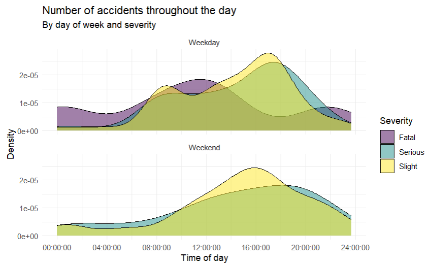

5. Create an appropriate visualization for the variable `speed_limit`. Consider carefully whether you should treat this variable as quantitative or categorical (you may want to make a few visualizations to explore this variable before creating your final visualization). Be sure to give your visualization an appropriate title and axis labels. What can you conclude from the visualization? Are the results surprising?
6. Create another data visualization based on these data and interpret it. You can choose any variables and any type of visualization you like, but it must have at least three variables, e.g. a scatterplot of x vs. y isn’t enough, but if points are colored by z, that’s fine. In your answer, don’t forget to label your R chunk as well. Be sure to interpret your visualization.

🧶 ✅ ⬆️ Knit, *commit, and push your changes to GitHub with an appropriate commit message. Make sure to commit and push all changed files so that your Git pane is cleared up afterwards.*